# Data Science II Midterm Project

Midterm Project Group 29

2026-03-24

# **Preparation and Inspection**

## Loading Data

```
## 'data.frame':    2000 obs. of  17 variables:
##  $ id              : chr  "A0001" "A0002" "A0003" "A0004" ...
##  $ age             : num  61.2 42 56.7 54 47 25 46.2 42.8 56.4 49.3 ...
##  $ menopause       : int  1 0 1 1 0 0 0 0 1 1 ...
##  $ race            : int  1 1 1 1 3 1 1 3 1 1 ...
##  $ bmi             : num  31.8 24 34.4 18.7 22.2 27.1 28.9 27 28.8 29.5 ...
##  $ tumor_size      : num  4.8 4.3 4.5 5.1 2.2 4.8 1.5 3 2.7 1.7 ...
##  $ tumor_grade     : int  3 3 1 2 1 3 2 2 1 2 ...
##  $ lymph_nodes     : int  6 2 2 11 0 6 0 1 0 1 ...
##  $ ER              : int  1 1 1 1 0 0 1 1 0 1 ...
##  $ PR              : int  1 1 1 1 0 0 1 1 0 1 ...
##  $ HER2            : int  0 0 1 0 0 0 0 0 1 0 ...
##  $ Ki67            : num  27.6 22.7 5 15.6 23.1 45.9 17.5 27.1 24.7 16.4 ...
##  $ stage           : int  3 3 2 3 1 3 1 1 2 1 ...
##  $ surgery         : int  1 0 0 1 0 0 0 0 1 0 ...
##  $ chemo           : int  1 1 0 1 1 0 0 0 1 0 ...
##  $ hormonal_therapy: int  1 0 1 1 0 0 1 1 0 1 ...
##  $ log_PFS         : num  1.33 2.13 1.61 2.59 4.08 ...
```

```
## 'data.frame':    2000 obs. of  17 variables:
##  $ id              : chr  "B0001" "B0002" "B0003" "B0004" ...
##  $ age             : num  46.5 39.7 56.5 58.5 70.4 58.7 53.1 75.1 56.5 60.3 ...
##  $ menopause       : int  0 0 1 1 1 1 0 1 1 1 ...
##  $ race            : int  1 1 4 2 2 1 4 1 3 1 ...
##  $ bmi             : num  26.8 26.8 31.2 23.9 28.3 29.7 17.8 22.8 33.9 27.8 ...
##  $ tumor_size      : num  2.6 3.5 2.9 3 3.7 2.4 7.1 3 6.7 2.1 ...
##  $ tumor_grade     : int  1 2 3 3 2 2 2 2 3 3 ...
##  $ lymph_nodes     : int  1 0 1 2 3 3 4 3 6 2 ...
##  $ ER              : int  0 1 0 0 1 1 1 1 0 0 ...
##  $ PR              : int  0 1 0 1 1 1 0 0 0 0 ...
##  $ HER2            : int  0 0 0 0 0 0 0 0 1 0 ...
##  $ Ki67            : num  1 23.2 34 33.3 14.4 15.2 30.6 15.9 30.1 9.4 ...
##  $ stage           : int  2 2 2 2 2 2 3 2 3 2 ...
##  $ surgery         : int  1 0 1 1 0 0 0 1 0 0 ...
##  $ chemo           : int  0 1 1 1 1 1 1 0 1 0 ...
##  $ hormonal_therapy: int  0 1 0 1 1 1 1 1 0 0 ...
##  $ log_PFS         : num  3.69 3.54 1.53 2.9 2.75 ...
```

## Set variable type, dimension, and data summary

```
## [1] 2000   17
```

```
##       id                 age        menopause race          bmi
##  Length:2000        Min.   :25.00   0: 689    1:1284   Min.   :16.00
##  Class :character   1st Qu.:47.00   1:1311    2: 289   1st Qu.:23.00
##  Mode  :character   Median :55.00             3: 176   Median :26.05
##                     Mean   :54.99             4: 251   Mean   :26.06
##                     3rd Qu.:62.40                      3rd Qu.:29.10
##                     Max.   :85.00                      Max.   :42.60
##    tumor_size    tumor_grade  lymph_nodes     ER       PR       HER2
##  Min.   :0.300   1:383       Min.   : 0.000   0: 719   0:1039   0:1556
##  1st Qu.:2.100   2:871       1st Qu.: 0.750   1:1281   1: 961   1: 444
##  Median :3.100   3:746       Median : 2.000
##  Mean   :3.384               Mean   : 2.623
##  3rd Qu.:4.800               3rd Qu.: 4.000
##  Max.   :8.300               Max.   :16.000
##       Ki67       stage   surgery  chemo    hormonal_therapy    log_PFS
##  Min.   : 1.00   1:504   0: 986   0: 895   0:1066           Min.   :-0.5345
##  1st Qu.:13.50   2:893   1:1014   1:1105   1: 934           1st Qu.: 1.6724
##  Median :21.60   3:603                                      Median : 2.1911
##  Mean   :21.85                                              Mean   : 2.1957
##  3rd Qu.:29.90                                              3rd Qu.: 2.7125
##  Max.   :62.30                                              Max.   : 5.1013
```

```
## [1] 2000   17
```

```
##       id                 age        menopause race          bmi
##  Length:2000        Min.   :25.00   0: 638    1:1097   Min.   :16.00
##  Class :character   1st Qu.:48.50   1:1362    2: 369   1st Qu.:24.00
##  Mode  :character   Median :56.00             3: 220   Median :27.30
##                     Mean   :56.05             4: 314   Mean   :27.44
##                     3rd Qu.:63.80                      3rd Qu.:30.82
##                     Max.   :85.00                      Max.   :45.90
##    tumor_size    tumor_grade  lymph_nodes     ER       PR       HER2
##  Min.   :0.300   1:502       Min.   : 0.000   0: 652   0: 991   0:1526
##  1st Qu.:1.800   2:839       1st Qu.: 0.000   1:1348   1:1009   1: 474
##  Median :2.800   3:659       Median : 2.000
##  Mean   :3.075               Mean   : 2.318
##  3rd Qu.:4.200               3rd Qu.: 4.000
##  Max.   :7.900               Max.   :15.000
##       Ki67       stage   surgery  chemo    hormonal_therapy    log_PFS
##  Min.   : 1.00   1:692   0:1117   0: 702   0: 861           Min.   :-0.0866
##  1st Qu.:11.70   2:828   1: 883   1:1298   1:1139           1st Qu.: 2.2536
##  Median :19.85   3:480                                      Median : 2.7440
##  Mean   :20.37                                              Mean   : 2.7424
##  3rd Qu.:28.80                                              3rd Qu.: 3.2487
##  Max.   :62.30                                              Max.   : 5.2864
```

## Check for Missing Data

```
##               id              age        menopause             race
##                0                0                0                0
##              bmi       tumor_size      tumor_grade      lymph_nodes
##                0                0                0                0
##               ER               PR             HER2             Ki67
##                0                0                0                0
##            stage          surgery            chemo hormonal_therapy
##                0                0                0                0
##          log_PFS
##                0
```

```
##               id              age        menopause             race
##                0                0                0                0
##              bmi       tumor_size      tumor_grade      lymph_nodes
##                0                0                0                0
##               ER               PR             HER2             Ki67
##                0                0                0                0
##            stage          surgery            chemo hormonal_therapy
##                0                0                0                0
##          log_PFS
##                0
```

# **Part 1: PFS model (1990 - 1995)**

## *○ Data Partition*

### Data Visualization and featurePlot

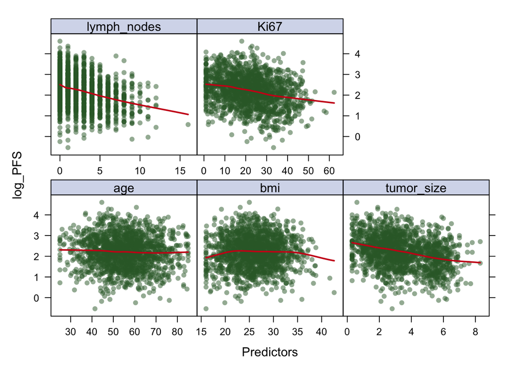

While looking at the features plots, we can observe that:

`lymph_nodes`: negative relationship with log_PFS — more positive lymph nodes, shorter PFS. The trend appears approximately linear.

`Ki67`: negative relationship with log_PFS. Higher proliferation index associated with shorter PFS, though the trend is relatively mild.

`age`: very weak relationship. Smooth curve is flat.

`tumor_size`: ngeative relationship. larger tumor size associated with shorter PFS.

```
##                     [,1]
## age         -0.052177434
## bmi          0.009478872
## tumor_size  -0.301980410
## lymph_nodes -0.316423346
## Ki67        -0.270877871
```

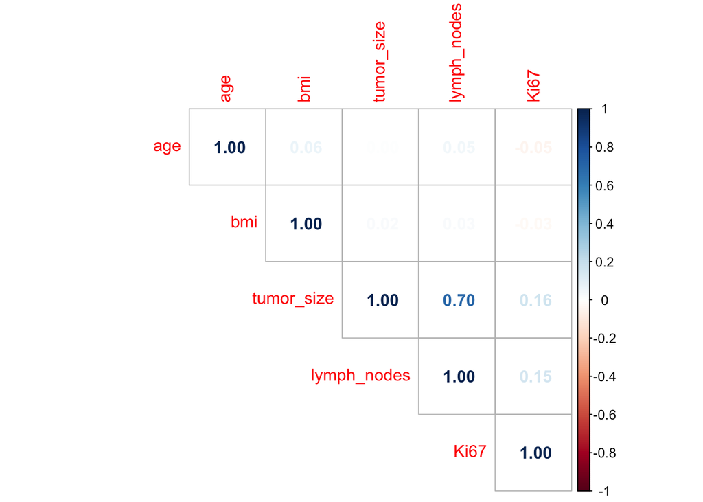

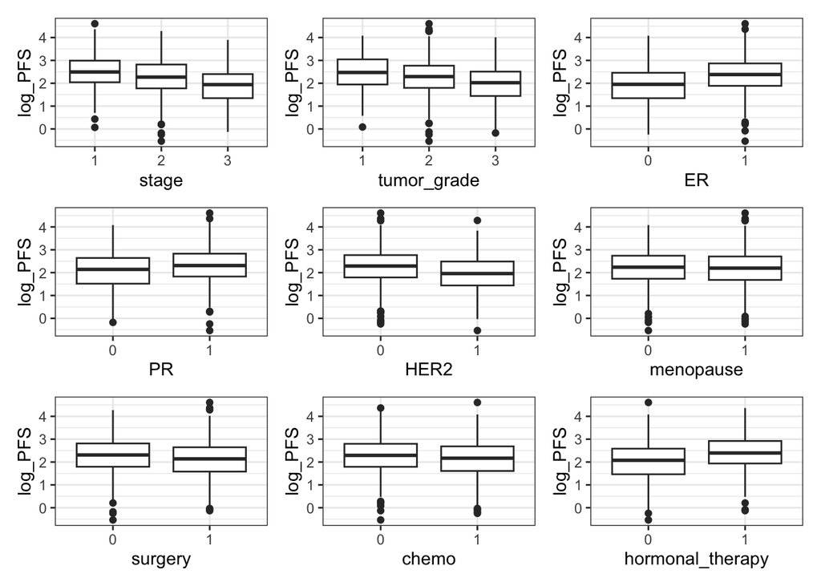

Notice that:

`stage`: Stage 1 patients having the highest log_PFS and Stage 3 the lowest (F = 81.0, p < 0.001), more advanced disease stage is associated with shorter PFS.

`tumor_grade`: Grade 1 patients had notably higher log_PFS, poorer tumor differentiation is associated with worse prognosis.

`ER`: ER-positive patients had substantially higher log_PFS than ER-negative patients (F = 138.4, p < 0.001)

`hormonal_therapy`: Patients receiving hormonal therapy had markedly higher log_PFS (F = 89.6, p < 0.001)

### ANOVA

```
##           Variable F_value P_value
## 1            stage  80.999  0.0000
## 2      tumor_grade  50.177  0.0000
## 3               ER 138.382  0.0000
## 4               PR  32.113  0.0000
## 5             HER2  44.093  0.0000
## 6        menopause   0.191  0.6624
## 7          surgery  22.783  0.0000
## 8            chemo  10.346  0.0013
## 9 hormonal_therapy  89.574  0.0000
```

## resampling and re-build the models

```
##
## Call:
## summary.resamples(object = resamp)
##
## Models: LM, Ridge, Lasso, ENet, GAM, MARS
## Number of resamples: 50
##
## MAE
##            Min.   1st Qu.    Median      Mean   3rd Qu.      Max. NA's
## LM    0.4962733 0.5325764 0.5574121 0.5548770 0.5712901 0.6081938    0
## Ridge 0.5011473 0.5320295 0.5549987 0.5549912 0.5734176 0.6091614    0
## Lasso 0.5036362 0.5330833 0.5581121 0.5552821 0.5730594 0.6103856    0
## ENet  0.5028572 0.5331709 0.5570546 0.5550002 0.5730948 0.6097850    0
## GAM   0.5026573 0.5307596 0.5557520 0.5521800 0.5689343 0.6058816    0
## MARS  0.5100593 0.5359815 0.5640580 0.5601673 0.5783102 0.6141880    0
##
## RMSE
##            Min.   1st Qu.    Median      Mean   3rd Qu.      Max. NA's
## LM    0.6381055 0.6657560 0.6971796 0.6934962 0.7141223 0.7721480    0
## Ridge 0.6392963 0.6668729 0.6974462 0.6928453 0.7131408 0.7698971    0
## Lasso 0.6360307 0.6653963 0.6970718 0.6922871 0.7116611 0.7675923    0
## ENet  0.6370070 0.6653186 0.6965452 0.6921751 0.7120675 0.7678068    0
## GAM   0.6211459 0.6681566 0.6913117 0.6892633 0.7067911 0.7604746    0
## MARS  0.6318979 0.6749862 0.6998830 0.6982097 0.7170147 0.7709148    0
##
## Rsquared
##             Min.   1st Qu.    Median      Mean   3rd Qu.      Max. NA's
## LM    0.10422714 0.1680350 0.2074370 0.2051977 0.2395478 0.3542000    0
## Ridge 0.10302868 0.1688026 0.2038002 0.2063767 0.2399801 0.3477520    0
## Lasso 0.10461157 0.1733668 0.2090786 0.2077842 0.2387177 0.3440153    0
## ENet  0.10400207 0.1724183 0.2082999 0.2081804 0.2391155 0.3451217    0
## GAM   0.10013075 0.1793927 0.2095997 0.2148044 0.2490520 0.3701313    0
## MARS  0.06950203 0.1701134 0.1987306 0.1968354 0.2249142 0.3201614    0
```

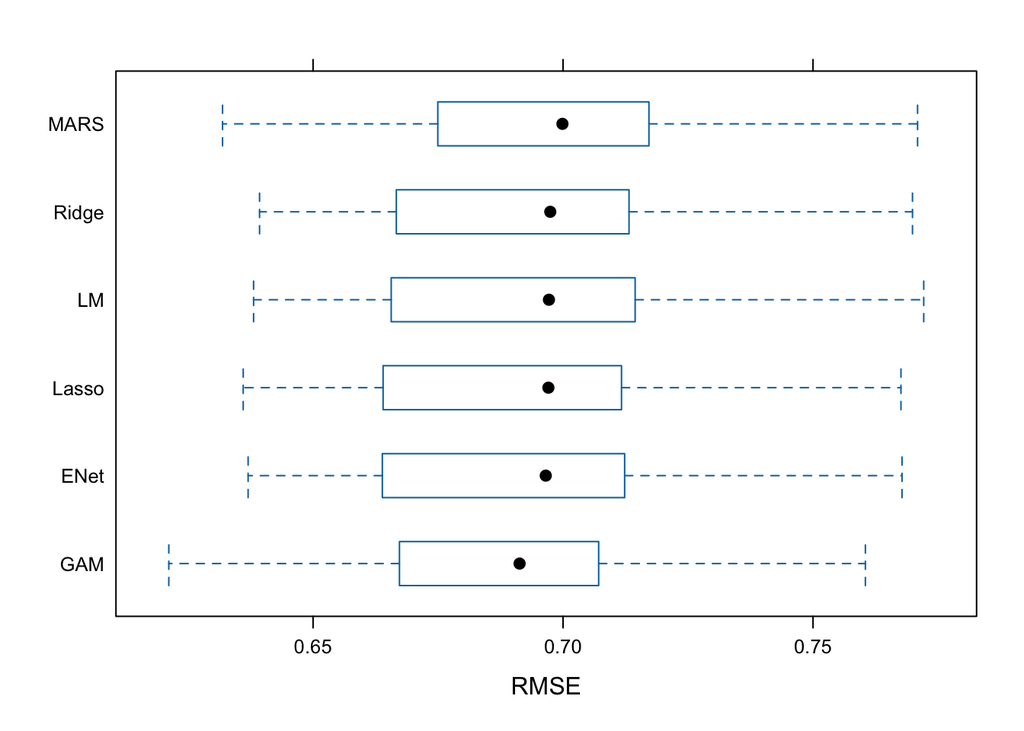

## Model selection based on the resampling results

If we choose to use GAM as the final model:

```
##
## Family: gaussian
## Link function: identity
##
## Formula:
## .outcome ~ menopause1 + race2 + race3 + race4 + tumor_grade2 +
##     tumor_grade3 + ER1 + PR1 + HER21 + stage2 + stage3 + surgery1 +
##     chemo1 + hormonal_therapy1 + s(lymph_nodes) + s(tumor_size) +
##     s(bmi) + s(Ki67) + s(age)
##
## Parametric coefficients:
##                    Estimate Std. Error t value Pr(>|t|)
## (Intercept)        2.064124   0.085336  24.188  < 2e-16 ***
## menopause1         0.060813   0.051741   1.175  0.24004
## race2              0.078155   0.049164   1.590  0.11210
## race3              0.092519   0.062178   1.488  0.13696
## race4             -0.042246   0.052874  -0.799  0.42441
## tumor_grade2      -0.072889   0.051044  -1.428  0.15350
## tumor_grade3      -0.176677   0.065561  -2.695  0.00712 **
## ER1                0.242558   0.057105   4.248 2.29e-05 ***
## PR1               -0.028336   0.042651  -0.664  0.50655
## HER21             -0.205080   0.042287  -4.850 1.36e-06 ***
## stage2             0.036962   0.057158   0.647  0.51795
## stage3             0.090455   0.112130   0.807  0.41996
## surgery1          -0.039580   0.036655  -1.080  0.28040
## chemo1             0.004067   0.035795   0.114  0.90955
## hormonal_therapy1  0.128418   0.043718   2.937  0.00336 **
## ---
## Signif. codes:  0 '***' 0.001 '**' 0.01 '*' 0.05 '.' 0.1 ' ' 1
##
## Approximate significance of smooth terms:
##                  edf Ref.df      F  p-value
## s(lymph_nodes) 1.000  1.000 27.684 4.74e-07 ***
## s(tumor_size)  1.000  1.000 10.074  0.00153 **
## s(bmi)         6.054  7.165  4.790 2.28e-05 ***
## s(Ki67)        1.000  1.000  5.286  0.02163 *
## s(age)         1.000  1.000  5.189  0.02287 *
## ---
## Signif. codes:  0 '***' 0.001 '**' 0.01 '*' 0.05 '.' 0.1 ' ' 1
##
## R-sq.(adj) =  0.225   Deviance explained = 23.7%
## GCV = 0.47437  Scale est. = 0.46694   n = 1600
```

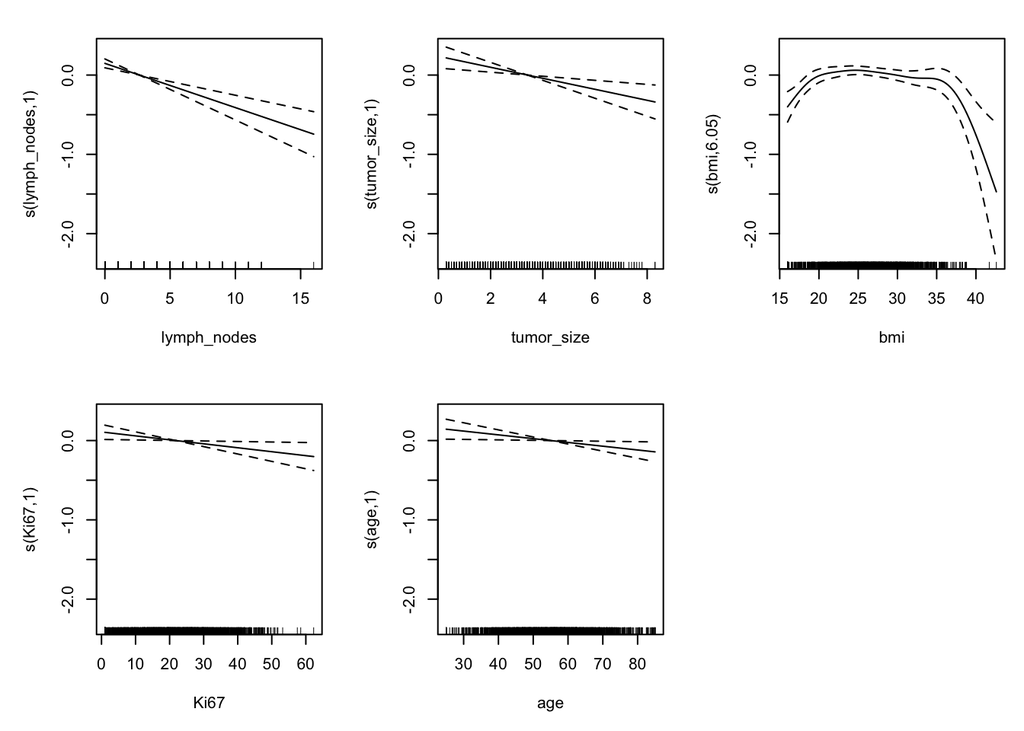

```
## [1] 0.7435168
```

```
## [1] 0.1642437
```

## Generalization GAM on datB

```r
## generalization on datB
# GAM trained on datA, predict on entire datB
gam_pred_datB <- predict(gam_fit, newdata = datB)

gam_rmse_datB <- sqrt(mean((datB$log_PFS - gam_pred_datB)^2))
gam_r2_datB <- cor(datB$log_PFS, gam_pred_datB)^2

gam_rmse_datB
```

```
## [1] 0.840068
```

```r
gam_r2_datB
```

```
## [1] 0.154838
```

## split

```r
set.seed(123)
datsplit_b <- initial_split(datB, prop = 0.8)
train_b <- training(datsplit_b) |> select(-id)
test_b  <- testing(datsplit_b) |> select(-id)
```

## re-build models on datB

```r
# resampling setup
set.seed(123)
folds_b <- createMultiFolds(train_b$log_PFS, k = 10, times = 5)
ctrl_b <- trainControl(
  method = "repeatedcv",
  number = 10,
  repeats = 5,
  index = folds_b
)

# LM
lm_fit_b <- train(log_PFS ~ ., data = train_b, method = "lm", metric = "RMSE", trControl = ctrl_b)
# Ridge
ridge_fit_b <- train(log_PFS ~ ., data = train_b, method = "glmnet", metric = "RMSE",
                     tuneGrid = expand.grid(alpha = 0, lambda = exp(seq(-5, 5, length = 50))),
                     trControl = ctrl_b)
# Lasso
lasso_fit_b <- train(log_PFS ~ ., data = train_b, method = "glmnet", metric = "RMSE",
                     tuneGrid = expand.grid(alpha = 1, lambda = exp(seq(-5, 2, length = 50))),
                     trControl = ctrl_b)
# Elastic Net
enet_fit_b <- train(log_PFS ~ ., data = train_b, method = "glmnet", metric = "RMSE",
                    tuneGrid = expand.grid(alpha = seq(0, 1, length = 11),
                                           lambda = exp(seq(-5, 5, length = 50))),
                    trControl = ctrl_b)
# GAM
gam_fit_b <- train(log_PFS ~ ., data = train_b, method = "gam", metric = "RMSE", trControl = ctrl_b)
# MARS
mars_fit_b <- train(log_PFS ~ ., data = train_b, method = "earth", metric = "RMSE",
                    tuneGrid = expand.grid(degree = 1:3, nprune = 2:20),
                    trControl = ctrl_b)

# compare
resamp_b <- resamples(list(LM = lm_fit_b, Ridge = ridge_fit_b, Lasso = lasso_fit_b,
                           ENet = enet_fit_b, GAM = gam_fit_b, MARS = mars_fit_b))
summary(resamp_b)
```

```
##
## Call:
## summary.resamples(object = resamp_b)
##
## Models: LM, Ridge, Lasso, ENet, GAM, MARS
## Number of resamples: 50
##
## MAE
##            Min.   1st Qu.    Median      Mean   3rd Qu.      Max. NA's
## LM    0.4577066 0.5153166 0.5254589 0.5247340 0.5354314 0.5767516    0
## Ridge 0.4625812 0.5146315 0.5264451 0.5238728 0.5334051 0.5700600    0
## Lasso 0.4609747 0.5161153 0.5258329 0.5237806 0.5332668 0.5718899    0
## ENet  0.4625812 0.5146315 0.5264451 0.5238728 0.5334051 0.5700600    0
## GAM   0.4605715 0.5107385 0.5220598 0.5223793 0.5341737 0.5738752    0
## MARS  0.4624646 0.5104734 0.5214361 0.5228766 0.5362399 0.5789288    0
##
## RMSE
##            Min.   1st Qu.    Median      Mean   3rd Qu.      Max. NA's
## LM    0.5771560 0.6410196 0.6553600 0.6570379 0.6719280 0.7219398    0
## Ridge 0.5792596 0.6392098 0.6550445 0.6555186 0.6727107 0.7129985    0
## Lasso 0.5784961 0.6403710 0.6552656 0.6560840 0.6730851 0.7172784    0
## ENet  0.5792596 0.6392098 0.6550445 0.6555186 0.6727107 0.7129985    0
## GAM   0.5761268 0.6392262 0.6489585 0.6531563 0.6701874 0.7216828    0
## MARS  0.5813993 0.6357279 0.6501705 0.6548886 0.6706589 0.7280406    0
##
## Rsquared
##             Min.   1st Qu.    Median      Mean   3rd Qu.      Max. NA's
## LM    0.06062592 0.1490517 0.1883065 0.1806123 0.2108733 0.2805334    0
## Ridge 0.05870501 0.1580626 0.1883819 0.1843176 0.2147675 0.2890484    0
## Lasso 0.06050890 0.1524987 0.1918682 0.1826220 0.2104570 0.2903568    0
## ENet  0.05870501 0.1580626 0.1883819 0.1843176 0.2147675 0.2890484    0
## GAM   0.06403179 0.1682200 0.1951541 0.1903121 0.2204090 0.2733632    0
## MARS  0.07395548 0.1652257 0.1871550 0.1853325 0.2153966 0.2575069    0
```

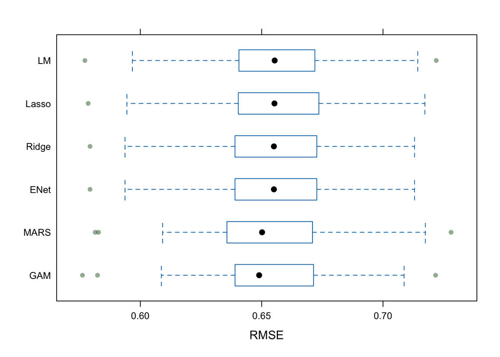

```r
bwplot(resamp_b, metric = "RMSE")
```

## GAM comparison across cohorts

```r
# datA GAM summary and smooth curves
summary(gam_fit$finalModel)
```

```
##
## Family: gaussian
## Link function: identity
##
## Formula:
## .outcome ~ menopause1 + race2 + race3 + race4 + tumor_grade2 +
##     tumor_grade3 + ER1 + PR1 + HER21 + stage2 + stage3 + surgery1 +
##     chemo1 + hormonal_therapy1 + s(lymph_nodes) + s(tumor_size) +
##     s(bmi) + s(Ki67) + s(age)
##
## Parametric coefficients:
##                    Estimate Std. Error t value Pr(>|t|)
## (Intercept)        2.064124   0.085336  24.188  < 2e-16 ***
## menopause1         0.060813   0.051741   1.175  0.24004
## race2              0.078155   0.049164   1.590  0.11210
## race3              0.092519   0.062178   1.488  0.13696
## race4             -0.042246   0.052874  -0.799  0.42441
## tumor_grade2      -0.072889   0.051044  -1.428  0.15350
## tumor_grade3      -0.176677   0.065561  -2.695  0.00712 **
## ER1                0.242558   0.057105   4.248 2.29e-05 ***
## PR1               -0.028336   0.042651  -0.664  0.50655
## HER21             -0.205080   0.042287  -4.850 1.36e-06 ***
## stage2             0.036962   0.057158   0.647  0.51795
## stage3             0.090455   0.112130   0.807  0.41996
## surgery1          -0.039580   0.036655  -1.080  0.28040
## chemo1             0.004067   0.035795   0.114  0.90955
## hormonal_therapy1  0.128418   0.043718   2.937  0.00336 **
## ---
## Signif. codes:  0 '***' 0.001 '**' 0.01 '*' 0.05 '.' 0.1 ' ' 1
##
## Approximate significance of smooth terms:
##                  edf Ref.df      F  p-value
## s(lymph_nodes) 1.000  1.000 27.684 4.74e-07 ***
## s(tumor_size)  1.000  1.000 10.074  0.00153 **
## s(bmi)         6.054  7.165  4.790 2.28e-05 ***
## s(Ki67)        1.000  1.000  5.286  0.02163 *
## s(age)         1.000  1.000  5.189  0.02287 *
## ---
## Signif. codes:  0 '***' 0.001 '**' 0.01 '*' 0.05 '.' 0.1 ' ' 1
##
## R-sq.(adj) =  0.225   Deviance explained = 23.7%
## GCV = 0.47437  Scale est. = 0.46694   n = 1600
```

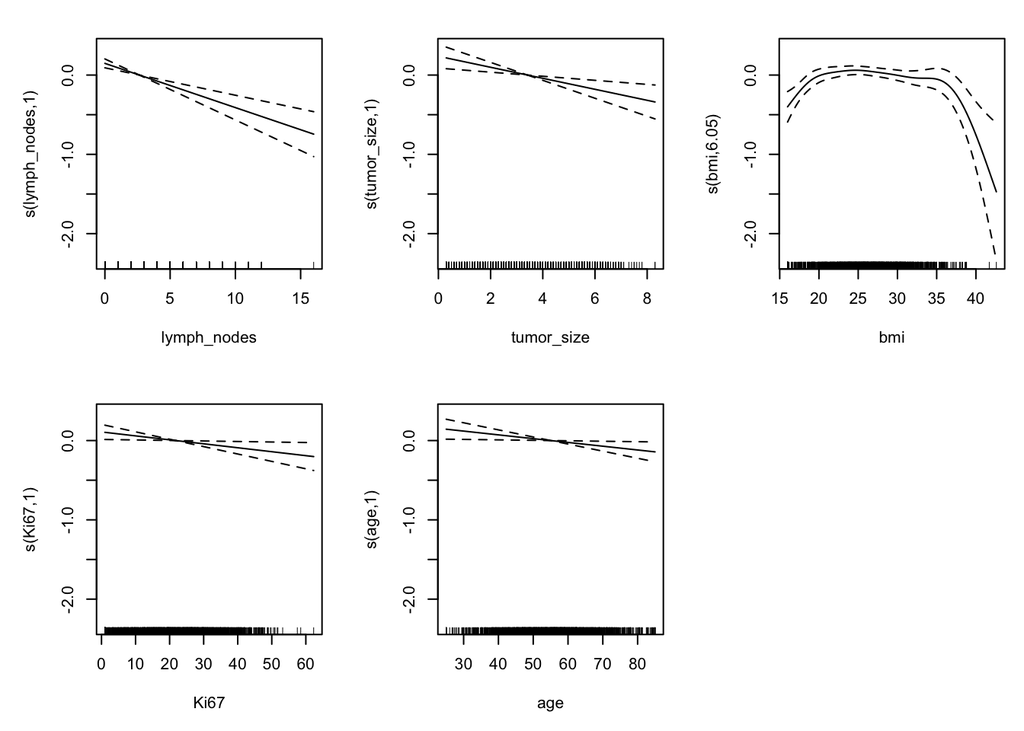

```r
plot(gam_fit$finalModel, pages = 1)
```

```r
# datB GAM summary and smooth curves
summary(gam_fit_b$finalModel)
```

```
##
## Family: gaussian
## Link function: identity
##
## Formula:
## .outcome ~ menopause1 + race2 + race3 + race4 + tumor_grade2 +
##     tumor_grade3 + ER1 + PR1 + HER21 + stage2 + stage3 + surgery1 +
##     chemo1 + hormonal_therapy1 + s(lymph_nodes) + s(tumor_size) +
##     s(bmi) + s(Ki67) + s(age)
##
## Parametric coefficients:
##                    Estimate Std. Error t value Pr(>|t|)
## (Intercept)        2.515167   0.075801  33.181  < 2e-16 ***
## menopause1         0.016217   0.047417   0.342  0.73238
## race2             -0.047899   0.043347  -1.105  0.26931
## race3             -0.031496   0.054527  -0.578  0.56361
## race4              0.085733   0.046542   1.842  0.06565 .
## tumor_grade2       0.071230   0.046695   1.525  0.12735
## tumor_grade3      -0.122519   0.063557  -1.928  0.05407 .
## ER1                0.167560   0.061323   2.732  0.00636 **
## PR1                0.051000   0.040161   1.270  0.20432
## HER21              0.028360   0.039401   0.720  0.47177
## stage2            -0.003761   0.057831  -0.065  0.94816
## stage3            -0.060314   0.115998  -0.520  0.60317
## surgery1          -0.018521   0.034962  -0.530  0.59636
## chemo1            -0.025247   0.037244  -0.678  0.49795
## hormonal_therapy1  0.220316   0.049668   4.436 9.81e-06 ***
## ---
## Signif. codes:  0 '***' 0.001 '**' 0.01 '*' 0.05 '.' 0.1 ' ' 1
##
## Approximate significance of smooth terms:
##                  edf Ref.df     F p-value
## s(lymph_nodes) 1.701  2.148 2.669  0.0632 .
## s(tumor_size)  1.844  2.365 2.696  0.0577 .
## s(bmi)         3.112  3.941 7.534 8.7e-06 ***
## s(Ki67)        1.509  1.871 1.677  0.1384
## s(age)         1.000  1.000 3.499  0.0616 .
## ---
## Signif. codes:  0 '***' 0.001 '**' 0.01 '*' 0.05 '.' 0.1 ' ' 1
##
## R-sq.(adj) =  0.201   Deviance explained = 21.3%
## GCV = 0.42576  Scale est. = 0.41933   n = 1600
```

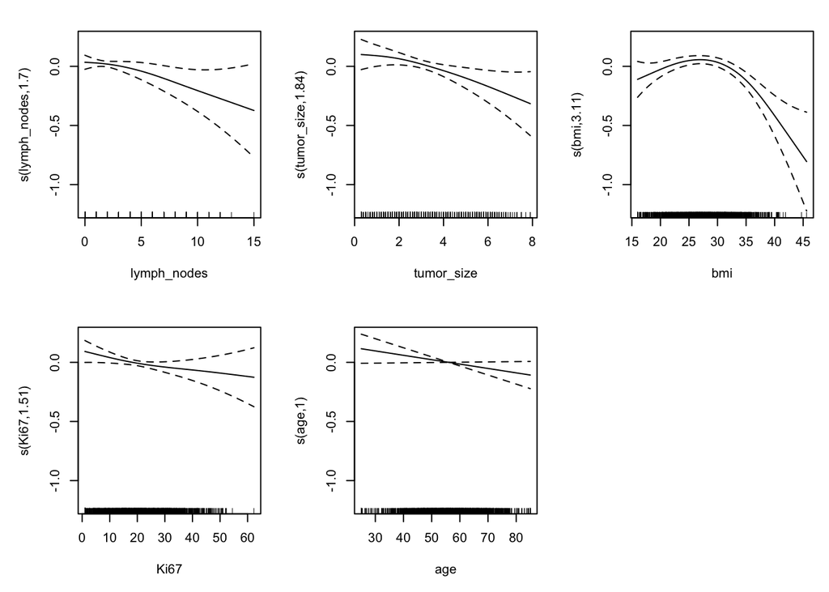

```r
plot(gam_fit_b$finalModel, pages = 1)
```

```r
# datB test set evaluation
gam_pred_b <- predict(gam_fit_b, newdata = test_b)
gam_test_rmse_b <- sqrt(mean((test_b$log_PFS - gam_pred_b)^2))
gam_test_r2_b <- cor(test_b$log_PFS, gam_pred_b)^2
gam_test_rmse_b
```

```
## [1] 0.731265
```

```r
gam_test_r2_b
```

```
## [1] 0.1406592
```

GAM before generalization RMSE: 0.840 after: 0.731265

## Model selection based on the resampling results

If we want to choose LASSO as our final model:

```r
# if we choose to use LASSO as the final model (because of easier interpretation)
lasso_pred <- predict(lasso_fit, newdata = test)
lasso_test_rmse <- sqrt(mean((test$log_PFS - lasso_pred)^2))
lasso_test_r2 <- cor(test$log_PFS, lasso_pred)^2

lasso_test_rmse
```

```
## [1] 0.7409103
```

```r
lasso_test_r2
```

```
## [1] 0.1670126
```

```r
# Lasso coefficients
coef(lasso_fit$finalModel, lasso_fit$bestTune$lambda)
```

```
## 20 x 1 sparse Matrix of class "dgCMatrix"
##                   s=0.01186285
## (Intercept)        2.657150940
## age               -0.002054392
## menopause1         .
## race2              0.034665076
## race3              0.040004233
## race4             -0.024538538
## bmi                .
## tumor_size        -0.056838168
## tumor_grade2      -0.002679517
## tumor_grade3      -0.096225273
## lymph_nodes       -0.050768833
## ER1                0.208477782
## PR1                .
## HER21             -0.177361833
## Ki67              -0.005637774
## stage2             .
## stage3             .
## surgery1          -0.018630842
## chemo1             .
## hormonal_therapy1  0.122289007
```

## generalization on datB

```r
# if we select LASSO
lasso_pred_datB <- predict(lasso_fit, newdata = datB)

lasso_rmse_datB <- sqrt(mean((datB$log_PFS - lasso_pred_datB)^2))
lasso_r2_datB <- cor(datB$log_PFS, lasso_pred_datB)^2

lasso_rmse_datB
```

```
## [1] 0.8295412
```

```r
lasso_r2_datB
```

```
## [1] 0.1515466
```

## split

```r
set.seed(123)
datsplit_b <- initial_split(datB, prop = 0.8)
train_b <- training(datsplit_b) |> select(-id)
test_b  <- testing(datsplit_b) |> select(-id)
```

## re-build models on datB

```r
# resampling setup
set.seed(123)
folds_b <- createMultiFolds(train_b$log_PFS, k = 10, times = 5)
ctrl_b <- trainControl(
  method = "repeatedcv",
  number = 10,
  repeats = 5,
  index = folds_b
)

# LM
lm_fit_b <- train(log_PFS ~ ., data = train_b, method = "lm", metric = "RMSE", trControl = ctrl_b)
# Ridge
ridge_fit_b <- train(log_PFS ~ ., data = train_b, method = "glmnet", metric = "RMSE",
                     tuneGrid = expand.grid(alpha = 0, lambda = exp(seq(-5, 5, length = 50))),
                     trControl = ctrl_b)
# Lasso
lasso_fit_b <- train(log_PFS ~ ., data = train_b, method = "glmnet", metric = "RMSE",
                     tuneGrid = expand.grid(alpha = 1, lambda = exp(seq(-5, 2, length = 50))),
                     trControl = ctrl_b)
# Elastic Net
enet_fit_b <- train(log_PFS ~ ., data = train_b, method = "glmnet", metric = "RMSE",
                    tuneGrid = expand.grid(alpha = seq(0, 1, length = 11),
                                           lambda = exp(seq(-5, 5, length = 50))),
                    trControl = ctrl_b)
# GAM
gam_fit_b <- train(log_PFS ~ ., data = train_b, method = "gam", metric = "RMSE", trControl = ctrl_b)
# MARS
mars_fit_b <- train(log_PFS ~ ., data = train_b, method = "earth", metric = "RMSE",
                    tuneGrid = expand.grid(degree = 1:3, nprune = 2:20),
                    trControl = ctrl_b)

# compare
resamp_b <- resamples(list(LM = lm_fit_b, Ridge = ridge_fit_b, Lasso = lasso_fit_b,
                           ENet = enet_fit_b, GAM = gam_fit_b, MARS = mars_fit_b))
summary(resamp_b)
```

```
##
## Call:
## summary.resamples(object = resamp_b)
##
## Models: LM, Ridge, Lasso, ENet, GAM, MARS
## Number of resamples: 50
##
## MAE
##            Min.   1st Qu.    Median      Mean   3rd Qu.      Max. NA's
## LM    0.4577066 0.5153166 0.5254589 0.5247340 0.5354314 0.5767516    0
## Ridge 0.4625812 0.5146315 0.5264451 0.5238728 0.5334051 0.5700600    0
## Lasso 0.4609747 0.5161153 0.5258329 0.5237806 0.5332668 0.5718899    0
## ENet  0.4625812 0.5146315 0.5264451 0.5238728 0.5334051 0.5700600    0
## GAM   0.4605715 0.5107385 0.5220598 0.5223793 0.5341737 0.5738752    0
## MARS  0.4624646 0.5104734 0.5214361 0.5228766 0.5362399 0.5789288    0
##
## RMSE
##            Min.   1st Qu.    Median      Mean   3rd Qu.      Max. NA's
## LM    0.5771560 0.6410196 0.6553600 0.6570379 0.6719280 0.7219398    0
## Ridge 0.5792596 0.6392098 0.6550445 0.6555186 0.6727107 0.7129985    0
## Lasso 0.5784961 0.6403710 0.6552656 0.6560840 0.6730851 0.7172784    0
## ENet  0.5792596 0.6392098 0.6550445 0.6555186 0.6727107 0.7129985    0
## GAM   0.5761268 0.6392262 0.6489585 0.6531563 0.6701874 0.7216828    0
## MARS  0.5813993 0.6357279 0.6501705 0.6548886 0.6706589 0.7280406    0
##
## Rsquared
##             Min.   1st Qu.    Median      Mean   3rd Qu.      Max. NA's
## LM    0.06062592 0.1490517 0.1883065 0.1806123 0.2108733 0.2805334    0
## Ridge 0.05870501 0.1580626 0.1883819 0.1843176 0.2147675 0.2890484    0
## Lasso 0.06050890 0.1524987 0.1918682 0.1826220 0.2104570 0.2903568    0
## ENet  0.05870501 0.1580626 0.1883819 0.1843176 0.2147675 0.2890484    0
## GAM   0.06403179 0.1682200 0.1951541 0.1903121 0.2204090 0.2733632    0
## MARS  0.07395548 0.1652257 0.1871550 0.1853325 0.2153966 0.2575069    0
```

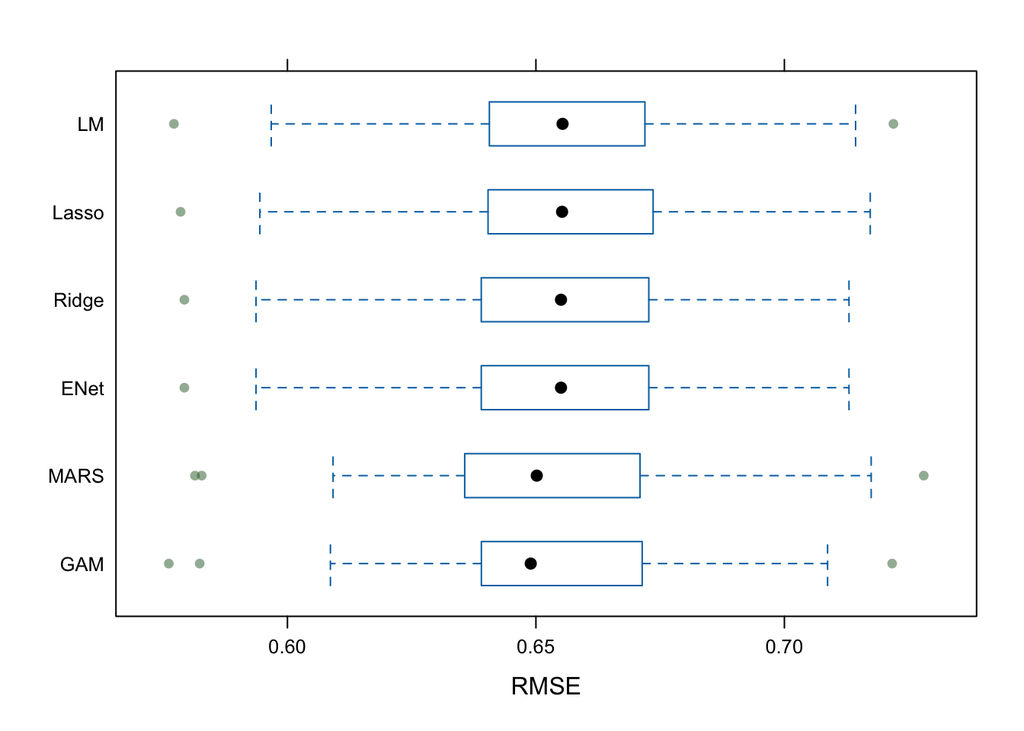

```r
bwplot(resamp_b, metric = "RMSE")
```

## coefficient of LASSO

```r
# datA coefficient lasso
coef(lasso_fit$finalModel, lasso_fit$bestTune$lambda)
```

```
## 20 x 1 sparse Matrix of class "dgCMatrix"
##                   s=0.01186285
## (Intercept)        2.657150940
## age               -0.002054392
## menopause1         .
## race2              0.034665076
## race3              0.040004233
## race4             -0.024538538
## bmi                .
## tumor_size        -0.056838168
## tumor_grade2      -0.002679517
## tumor_grade3      -0.096225273
## lymph_nodes       -0.050768833
## ER1                0.208477782
## PR1                .
## HER21             -0.177361833
## Ki67              -0.005637774
## stage2             .
## stage3             .
## surgery1          -0.018630842
## chemo1             .
## hormonal_therapy1  0.122289007
```

```r
# datB coefficient lasso
coef(lasso_fit_b$finalModel, lasso_fit_b$bestTune$lambda)
```

```
## 20 x 1 sparse Matrix of class "dgCMatrix"
##                   s=0.01193152
## (Intercept)        3.031920521
## age               -0.002264920
## menopause1         .
## race2             -0.007576486
## race3              .
## race4              0.067122900
## bmi               -0.004824225
## tumor_size        -0.039623661
## tumor_grade2       0.048829789
## tumor_grade3      -0.136519538
## lymph_nodes       -0.018338401
## ER1                0.157563964
## PR1                0.043290389
## HER21              0.002484468
## Ki67              -0.003153918
## stage2             .
## stage3            -0.112331222
## surgery1           .
## chemo1             .
## hormonal_therapy1  0.204403060
```

## coefficient of GAM

```r
# automatically non-linear variables by caret
# datA
summary(gam_fit$finalModel)
```

```
##
## Family: gaussian
## Link function: identity
##
## Formula:
## .outcome ~ menopause1 + race2 + race3 + race4 + tumor_grade2 +
##     tumor_grade3 + ER1 + PR1 + HER21 + stage2 + stage3 + surgery1 +
##     chemo1 + hormonal_therapy1 + s(lymph_nodes) + s(tumor_size) +
##     s(bmi) + s(Ki67) + s(age)
##
## Parametric coefficients:
##                    Estimate Std. Error t value Pr(>|t|)
## (Intercept)        2.064124   0.085336  24.188  < 2e-16 ***
## menopause1         0.060813   0.051741   1.175  0.24004
## race2              0.078155   0.049164   1.590  0.11210
## race3              0.092519   0.062178   1.488  0.13696
## race4             -0.042246   0.052874  -0.799  0.42441
## tumor_grade2      -0.072889   0.051044  -1.428  0.15350
## tumor_grade3      -0.176677   0.065561  -2.695  0.00712 **
## ER1                0.242558   0.057105   4.248 2.29e-05 ***
## PR1               -0.028336   0.042651  -0.664  0.50655
## HER21             -0.205080   0.042287  -4.850 1.36e-06 ***
## stage2             0.036962   0.057158   0.647  0.51795
## stage3             0.090455   0.112130   0.807  0.41996
## surgery1          -0.039580   0.036655  -1.080  0.28040
## chemo1             0.004067   0.035795   0.114  0.90955
## hormonal_therapy1  0.128418   0.043718   2.937  0.00336 **
## ---
## Signif. codes:  0 '***' 0.001 '**' 0.01 '*' 0.05 '.' 0.1 ' ' 1
##
## Approximate significance of smooth terms:
##                  edf Ref.df      F  p-value
## s(lymph_nodes) 1.000  1.000 27.684 4.74e-07 ***
## s(tumor_size)  1.000  1.000 10.074  0.00153 **
## s(bmi)         6.054  7.165  4.790 2.28e-05 ***
## s(Ki67)        1.000  1.000  5.286  0.02163 *
## s(age)         1.000  1.000  5.189  0.02287 *
## ---
## Signif. codes:  0 '***' 0.001 '**' 0.01 '*' 0.05 '.' 0.1 ' ' 1
##
## R-sq.(adj) =  0.225   Deviance explained = 23.7%
## GCV = 0.47437  Scale est. = 0.46694   n = 1600
```

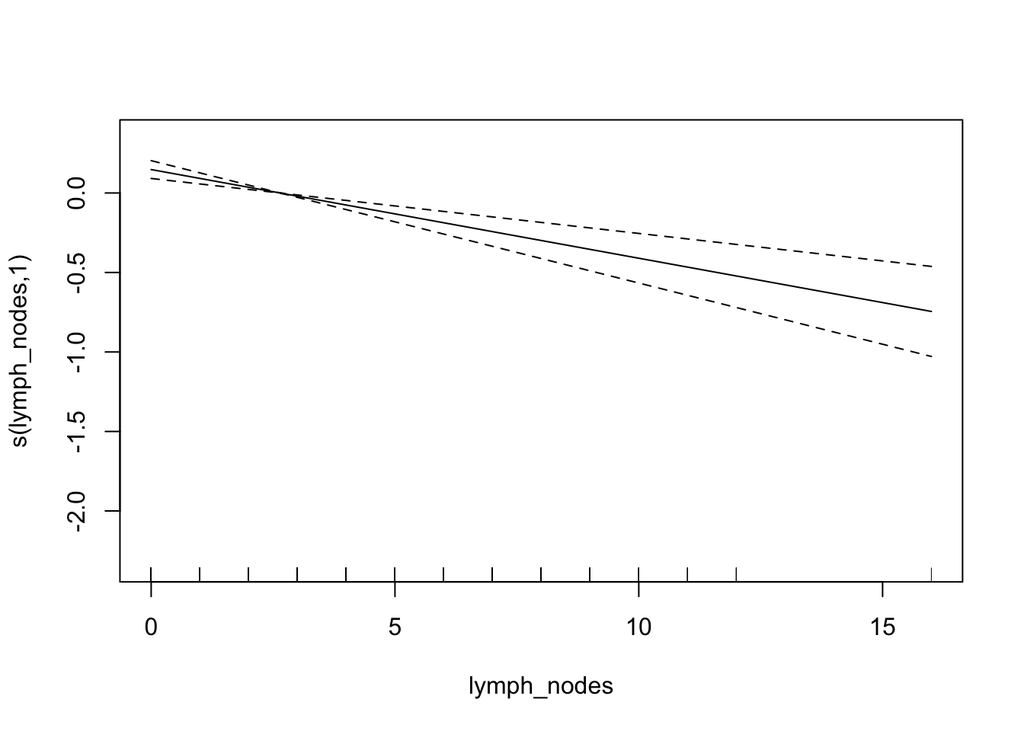

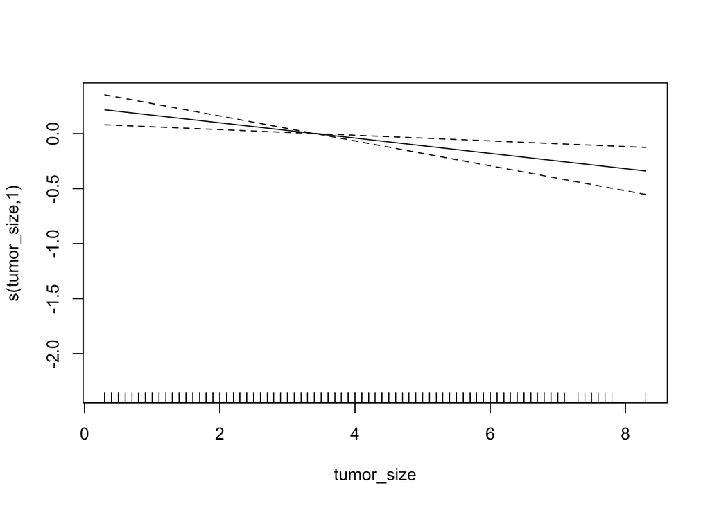

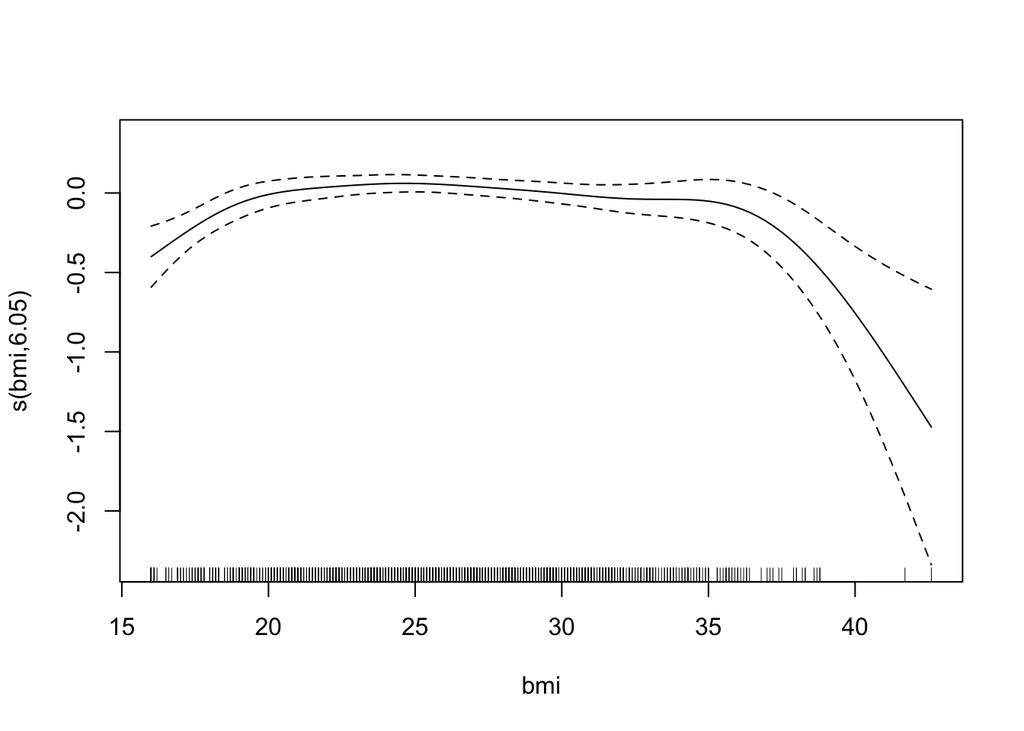

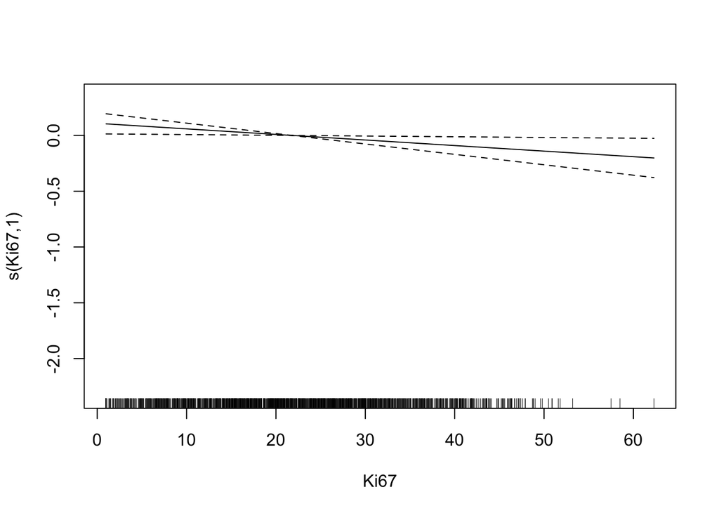

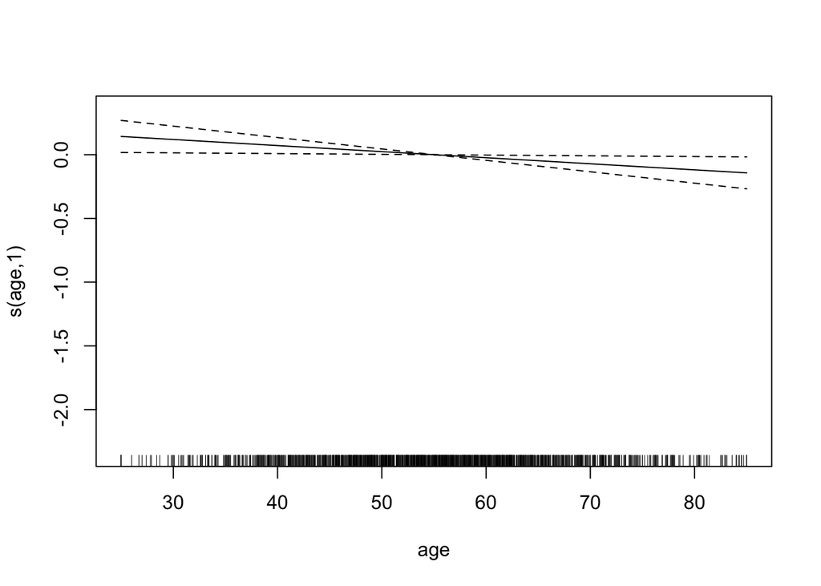

```r
plot(gam_fit$finalModel)
```

```r
#datB
summary(gam_fit_b$finalModel)
```

```
##
## Family: gaussian
## Link function: identity
##
## Formula:
## .outcome ~ menopause1 + race2 + race3 + race4 + tumor_grade2 +
##     tumor_grade3 + ER1 + PR1 + HER21 + stage2 + stage3 + surgery1 +
##     chemo1 + hormonal_therapy1 + s(lymph_nodes) + s(tumor_size) +
##     s(bmi) + s(Ki67) + s(age)
##
## Parametric coefficients:
##                    Estimate Std. Error t value Pr(>|t|)
## (Intercept)        2.515167   0.075801  33.181  < 2e-16 ***
## menopause1         0.016217   0.047417   0.342  0.73238
## race2             -0.047899   0.043347  -1.105  0.26931
## race3             -0.031496   0.054527  -0.578  0.56361
## race4              0.085733   0.046542   1.842  0.06565 .
## tumor_grade2       0.071230   0.046695   1.525  0.12735
## tumor_grade3      -0.122519   0.063557  -1.928  0.05407 .
## ER1                0.167560   0.061323   2.732  0.00636 **
## PR1                0.051000   0.040161   1.270  0.20432
## HER21              0.028360   0.039401   0.720  0.47177
## stage2            -0.003761   0.057831  -0.065  0.94816
## stage3            -0.060314   0.115998  -0.520  0.60317
## surgery1          -0.018521   0.034962  -0.530  0.59636
## chemo1            -0.025247   0.037244  -0.678  0.49795
## hormonal_therapy1  0.220316   0.049668   4.436 9.81e-06 ***
## ---
## Signif. codes:  0 '***' 0.001 '**' 0.01 '*' 0.05 '.' 0.1 ' ' 1
##
## Approximate significance of smooth terms:
##                  edf Ref.df     F p-value
## s(lymph_nodes) 1.701  2.148 2.669  0.0632 .
## s(tumor_size)  1.844  2.365 2.696  0.0577 .
## s(bmi)         3.112  3.941 7.534 8.7e-06 ***
## s(Ki67)        1.509  1.871 1.677  0.1384
## s(age)         1.000  1.000 3.499  0.0616 .
## ---
## Signif. codes:  0 '***' 0.001 '**' 0.01 '*' 0.05 '.' 0.1 ' ' 1
##
## R-sq.(adj) =  0.201   Deviance explained = 21.3%
## GCV = 0.42576  Scale est. = 0.41933   n = 1600
```

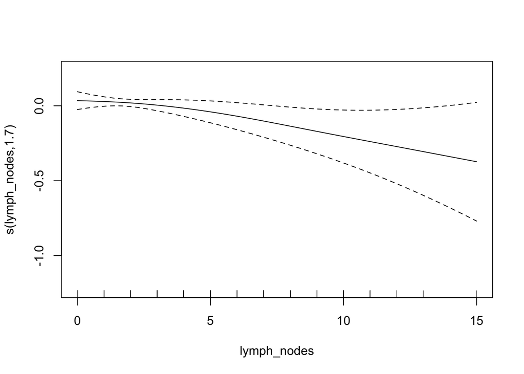

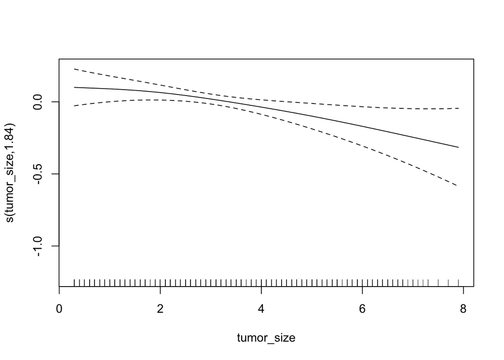

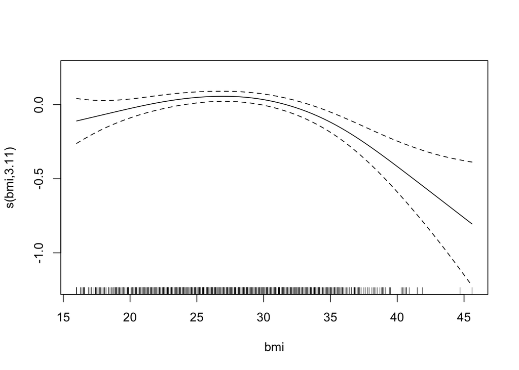

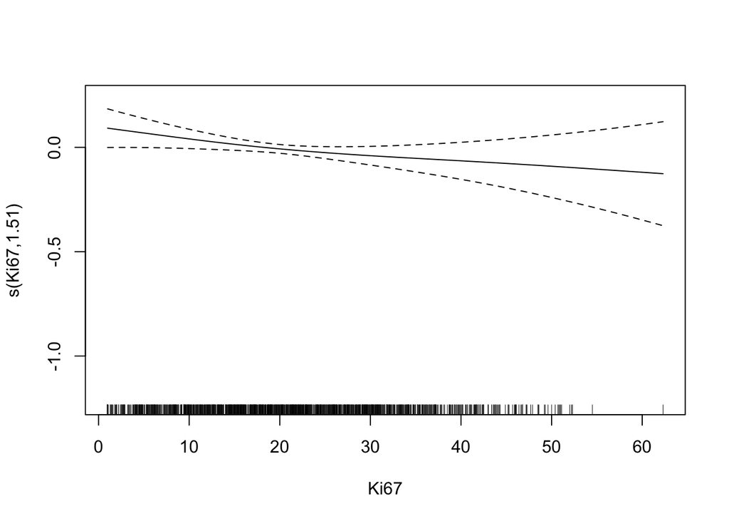

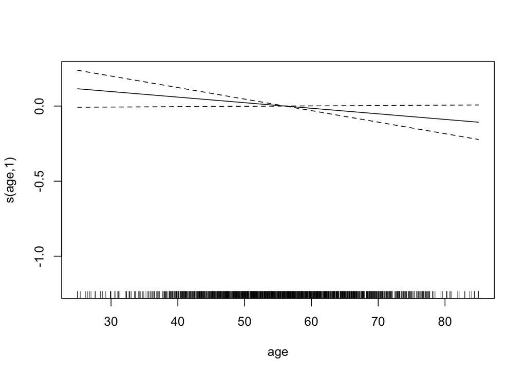

```r
plot(gam_fit_b$finalModel)
```

懒得打英语了hhh,可以对比一下lasso和gam,共同点: 1. HER2效应消失 2. bmi的非线性 我觉得重点我们可以解释模型的前后coefficient的变化